# IMMERSE day 4: text wrangling basics

Casey O’Hara

2023-05-13

```r
library(tidyverse)
library(here)
```

- intro to stringr
- intro to regex
- fix typos in state dataset and save back out

# Intro to `stringr` functions

Here we’ll play a little with some basic `stringr` functions, and pattern vs. vector of strings. Detecting strings (for filtering) and replacing/removing strings (for cleaning up text) are hugely helpful; other stringr functions certainly have their uses as well. Here we’re focusing on standardizing values in a character column so we can assign meaningful levels as a factor, to potentially use the column as a categorical variable.

- `str_match`, `str_match_all`
- `str_detect`
- `str_split`
- `str_replace`, `str_replace_all`
- `str_subset`, `str_count`, `str_locate`
- `str_trim`, `str_squish`
- `str_to_upper/lower/title/sentence`

Solicit pet names from the fellows to create a vector of character type; add in some random spaces and capitalization and punctuation

```r
x <- c("Waffle!!!", "teddy", "  scallop?!", "  taco   CAT   !")
stringr::str_to_title(x)
```

```
## [1] "Waffle!!!"        "Teddy"            "  Scallop?!"      "  Taco   Cat   !"
```

```r
str_to_lower(x)
```

```
## [1] "waffle!!!"        "teddy"            "  scallop?!"      "  taco   cat   !"
```

```r
str_squish(x) %>%
  str_to_upper()
```

```
## [1] "WAFFLE!!!"  "TEDDY"      "SCALLOP?!"  "TACO CAT !"
```

```r
str_squish(x) %>%
  str_to_sentence()
```

```
## [1] "Waffle!!!"  "Teddy"      "Scallop?!"  "Taco cat !"
```

```r
str_split(x, 'e'); str_split(x, 't')
```

```
## [[1]]
## [1] "Waffl" "!!!"
##
## [[2]]
## [1] "t"   "ddy"
##
## [[3]]
## [1] "  scallop?!"
##
## [[4]]
## [1] "  taco   CAT   !"
```

```
## [[1]]
## [1] "Waffle!!!"
##
## [[2]]
## [1] ""     "eddy"
##
## [[3]]
## [1] "  scallop?!"
##
## [[4]]
## [1] "  "            "aco   CAT   !"
```

```r
str_replace(x, 'e', 'Z')
```

```
## [1] "WafflZ!!!"        "tZddy"            "  scallop?!"      "  taco   CAT   !"
```

```r
str_replace(x, ' ', '_')
```

```
## [1] "Waffle!!!"        "teddy"            "_ scallop?!"      "_ taco   CAT   !"
```

```r
str_replace_all(x, ' ', '_')
```

```
## [1] "Waffle!!!"        "teddy"            "__scallop?!"      "__taco___CAT___!"
```

```r
str_replace_all(x, ' +', '_') ### replace one or more spaces with _
```

```
## [1] "Waffle!!!"   "teddy"       "_scallop?!"  "_taco_CAT_!"
```

```r
str_replace_all(str_squish(x), ' +|!+|\\?+', '_')
```

```
## [1] "Waffle_"    "teddy"      "scallop__"  "taco_CAT__"
```

```r
### more regular expressions in the self-guided tour for asynchronous session

str_detect(x, 't'); str_detect(x, 'dd|ll') ### is pattern in the string?
```

```
## [1] FALSE  TRUE FALSE  TRUE
```

```
## [1] FALSE  TRUE  TRUE FALSE
```

## OK now let’s put into practice! You do:

Read in the file of `ca_schools.csv` we created in the previous script. Fix the `county` column to some standard format (however you prefer). Note there is a typo in some instances of the Santa Barbara county name; identify those and fix those.

When finished, check the unique values found in the county column; there should be 45 unique values, no more, no less. Once you’ve figured out a standard format that works well, then write out as `ca_schools_clean.csv`.

```r
ca_schools <- read_csv(here('data/ca_schools.csv'))

# ca_schools$county %>% unique()

ca_schools_clean <- ca_schools %>%
  mutate(county = str_replace_all(county, '_', ' ')) %>%
  mutate(county = str_to_title(county)) %>%
  mutate(county = str_replace(county, 'Barabara', 'Barbara')) %>%
  mutate(county = factor(county))

ca_schools_clean$county %>% unique()
```

```
##  [1] Alameda         Butte           Calaveras       Contra Costa
##  [5] El Dorado       Fresno          Glenn           Humboldt
##  [9] Imperial        Inyo            Kern            Kings
## [13] Lake            Lassen          Los Angeles     Madera
## [17] Marin           Mendocino       Merced          Monterey
## [21] Nevada          Orange          Placer          Riverside
## [25] Sacramento      San Benito      San Bernardino  San Diego
## [29] San Joaquin     San Luis Obispo San Mateo       Santa Barbara
## [33] Santa Clara     Santa Cruz      Shasta          Siskiyou
## [37] Sonoma          Stanislaus      Sutter          Tehama
## [41] Trinity         Tulare          Tuolumne        Ventura
## [45] Yuba
## 45 Levels: Alameda Butte Calaveras Contra Costa El Dorado Fresno ... Yuba
```

```r
write_csv(ca_schools_clean, here('data/ca_schools_clean.csv'))
```

## A little more wrangling

Now that we have a clean dataset (back at the starting point of `AER::CASchools`), let’s do a little more wrangling using across() inside `mutate` and `summarize`:

```r
ca_by_county <- ca_schools_clean %>%
  mutate(s_t_ratio = students / teachers) %>%
  group_by(county) %>%
  # summarize(mean_s_t = mean(s_t_ratio))
  # summarize(across(.cols = students:math, .fns = mean))
  # summarize(across(.cols = c(students, math),
  #                  .fns = mean, .names = '{.col}_mean'))
  summarize(across(.cols = where(is.numeric),
                   .fns = list(mu = mean, sig = sd)))
```

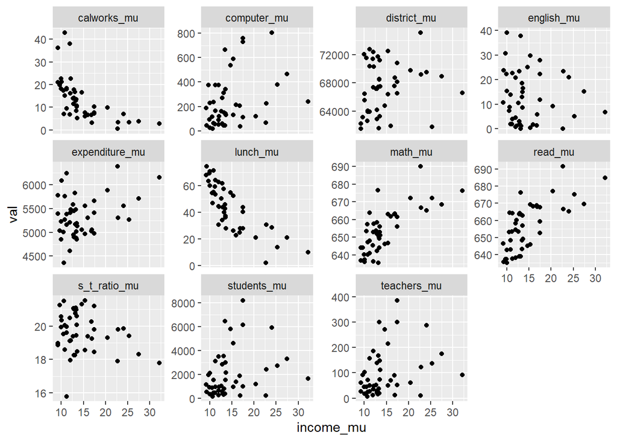

```r
ca_to_plot <- ca_by_county %>%
  select(-contains('sig')) %>%
  pivot_longer(names_to = 'var', values_to = 'val', cols = c(contains('mu'), -income_mu))
ggplot(ca_to_plot, aes(x = income_mu, y = val)) +
  geom_point() +
  facet_wrap(~ var, scales = 'free_y')
```

Take some time to pretty up the plot - add a theme, labels, colors, etc. ## Wrap up - any other text wrangling needs/questions?